# Introduction to Classification

## ROC Curves

An ROC curve plots the **true positive rate** versus the **false positive rate**. There are two important questions that an ROC curve helps to address:

1. What is the overall quality of classifier? The area under the ROC curve (AUC) provides a quantitative measure of this.
2. What is an effective theshold (decision criterion)? The ROC curve provides a visual representation of our complete space of options in putting together a classifier. So an ROC curve will help us to pick the best option.

There are several functions in the ROCR package that enable us to construct and ROC curve and to compute the AUC.

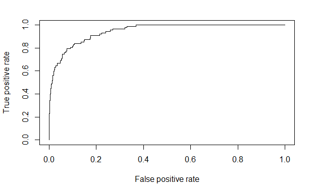

```r
temp_pred <- prediction(predict(default_glm_mod$finalModel,Default_test),Default_test$default)
temp_perf <- performance(temp_pred,"tpr","fpr")
plot(temp_perf)
```

To do this with ggplot we need to extract more information. One way to do this is as follows:

```r
temp_rates <- predict(default_glm_mod$finalModel,Default_test,type = "response") %>%
 prediction(Default_test$default) %>% performance("tpr","fpr")
fpr <- temp_rates@x.values[[1]]
tpr <- temp_rates@y.values[[1]]
threshold_vals <- temp_rates@alpha.values[[1]]
ROC_df <- data.frame(fpr=fpr,tpr=tpr,threshold_vals=threshold_vals)
```

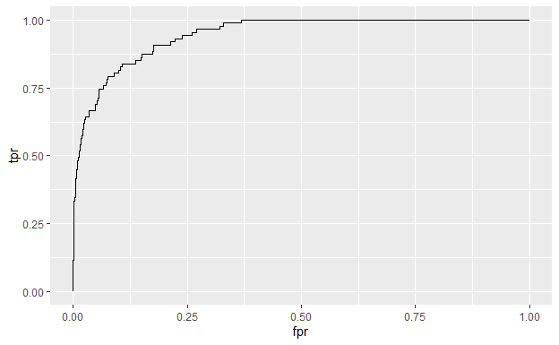

```r
ROC_df %>% ggplot(aes(x=fpr,y=tpr)) + geom_line()
```

Consider what happens as we increase our threshold from 0 to 1.

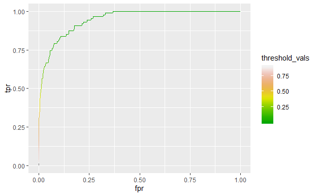

```r
ROC_df %>% ggplot(aes(x=fpr,y=tpr,color=threshold_vals)) +
  geom_line() +
  scale_colour_gradientn(colours = terrain.colors(10))
```

Every time we change our threshold value, we either increase the number of true positives (if this example was positive) or false positives (if this example was in fact a negative). At the very left, we achieve true/false positive rates of 0%, since the classifier labeled nothing as positive at that cutoff. Moving as far to the right as possible, all examples will be labeled positively, and hence both rates become 100%. Each threshold in between defines a possible classifier, and the sweep defines a staircase curve in true/false positive rate space taking us from (0%,0%) to (100%,100%).

This also explains why the area under the curve is a quantitative measure the effectiveness of a classification model.

This command computes the area under the ROC curve:

```r
predict(default_glm_mod$finalModel,Default_test,type = "response") %>%
 prediction(Default_test$default) %>% performance("auc") %>% attr("y.values")
```

```
[[1]]
[1] 0.9465015
```

**Note** The maximum possibel AUC is 1, the closer to 1, the more effective the classifier.

# KNN for Classification

This [online demo](https://codepen.io/gangtao/pen/PPoqMW) is very helful.

## KNN Applied to Iris

```r
train_ids <- createDataPartition(iris$Species,p=0.75,list = F)
iris_train <- iris[train_ids, ]
iris_test <- iris[-train_ids, ]
```

```r
tC <- trainControl(method="repeatedcv",number = 10,repeats = 5)
tG <- expand.grid(k=seq(1,25,by=2))
```

```r
train_result <- train(Species~.,data=iris_train,trControl=tC,tuneGrid=tG,method="knn",preProcess = c("center", "scale"))
```

```r
train_result$results
```

|  | k | Accuracy | Kappa | AccuracySD | KappaSD |
| --- | --- | --- | --- | --- | --- |
| 1 | 1 | 0.9610000 | 0.9411285 | 0.04821043 | 0.07281895 |
| 2 | 3 | 0.9628182 | 0.9438681 | 0.04792621 | 0.07240373 |
| 3 | 5 | 0.9644848 | 0.9463681 | 0.04773712 | 0.07213482 |
| 4 | 7 | 0.9664545 | 0.9494368 | 0.04341326 | 0.06546694 |
| 5 | 9 | 0.9734545 | 0.9599671 | 0.04104485 | 0.06192135 |
| 6 | 11 | 0.9734545 | 0.9599671 | 0.04104485 | 0.06192135 |
| 7 | 13 | 0.9716364 | 0.9571832 | 0.04570334 | 0.06903543 |
| 8 | 15 | 0.9681515 | 0.9518984 | 0.04674472 | 0.07064098 |
| 9 | 17 | 0.9681515 | 0.9518984 | 0.04674472 | 0.07064098 |
| 10 | 19 | 0.9642727 | 0.9463393 | 0.04876628 | 0.07298105 |

[output cut: 3 more lines]

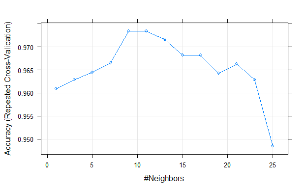

```r
plot(train_result)
```

```r
best_preds <- predict(train_result,newdata = iris_test[ ,1:4])

confusionMatrix(best_preds,iris_test$Species)
```

```
Confusion Matrix and Statistics

            Reference
Prediction   setosa versicolor virginica
  setosa         12          0         0
  versicolor      0         11         1
  virginica       0          1        11

Overall Statistics

               Accuracy : 0.9444
                 95% CI : (0.8134, 0.9932)
    No Information Rate : 0.3333
    P-Value [Acc > NIR] : 1.728e-14

                  Kappa : 0.9167

 Mcnemar's Test P-Value : NA

Statistics by Class:

                     Class: setosa Class: versicolor
Sensitivity                 1.0000            0.9167
Specificity                 1.0000            0.9583
Pos Pred Value              1.0000            0.9167
Neg Pred Value              1.0000            0.9583
Prevalence                  0.3333            0.3333
Detection Rate              0.3333            0.3056
Detection Prevalence        0.3333            0.3333
Balanced Accuracy           1.0000            0.9375
                     Class: virginica
Sensitivity                    0.9167
Specificity                    0.9583
Pos Pred Value                 0.9167
Neg Pred Value                 0.9583
Prevalence                     0.3333
Detection Rate                 0.3056
Detection Prevalence           0.3333
Balanced Accuracy              0.9375
```

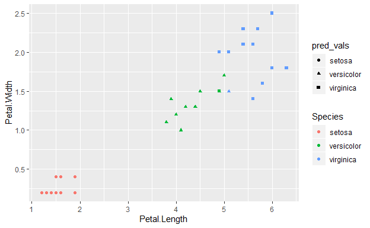

```r
iris_test$pred_vals <- best_preds

iris_test %>% ggplot(aes(x=Petal.Length,y=Petal.Width,color=Species,shape=pred_vals)) +
  geom_point()
```